# R Notebook Quantilille 2023

Module multiniveaux - Aspects géographiques

Clémentine Cottineau & Julie Vallée

30-06-2023

# Mise en place

## Chargement des packages:

```r
library(lme4) # pour la modélisation multiniveau
library(multilevelTools) # pour l'analyse des modèles
library(lmerTest) # pour l'évaluation des modèles
library(sf) # pour les objets spatiaux (cartes)
library(tidyverse) # pour la manipulation des données
library(readxl) # pour ouvrir les fichiers xlsx
library(ggrepel) # pour des étiquettes de graphiques propres
```

## Chargement des données:

### Jeu de données de niveau 1

Il s’agit des vignobles de Bourgogne. On a dans un tableau les caractéristiques de 2391 vignobles en termes de:

- prix moyen du vin
- qualité pédologique et météo (radiations solaires, pluie, etc.)
- appellation d’origine contrôlée en 5 niveaux (Côteaux bourgignons < Bourgogne < Village < Premier cru < Grand cru.)
- surface

```r
vignobles <- st_read("Data/Geo/Vignobles_prix.shp",
                     stringsAsFactors = T) %>%
  st_transform(crs = "EPSG:2154")
summary(vignobles)
```

```
##                              Concat                     LIBCOM
##  1AUXEY-DURESSESCORLOIN         :   1   MEURSAULT          : 158
##  1AUXEY-DURESSESDERRIERE LE BOIS:   1   GEVREY-CHAMBERTIN  : 128
##  1AUXEY-DURESSESEN CHAIGNUT     :   1   BEAUNE             : 126
##  1AUXEY-DURESSESEN FRIVOLE      :   1   NUITS-SAINT-GEORGES: 121
##  1AUXEY-DURESSESEN MORVIN       :   1   SAINT-AUBIN        : 121
##  1AUXEY-DURESSESEN POCHENOT     :   1   (Other)            :1727
##  (Other)                        :2385   NA's               :  10
##             NOM               NIVEAU        SURFACE          SCORE_b
##  LE VILLAGE   :  26   Bourgogne  : 624   Min.   :0.0000   Min.   :18.40
##  LES CRAIS    :  10   Coteaux b. : 319   1st Qu.:0.1300   1st Qu.:67.90
##  LES CRAS     :   8   Grand cru  :  37   Median :0.3100   Median :73.20
##  SOUS LA VELLE:   8   Premier cru: 410   Mean   :0.4773   Mean   :71.89
##  LES PERRIERES:   7   Village    :1001   3rd Qu.:0.6100   3rd Qu.:76.60
##  (Other)      :2331                      Max.   :7.2000   Max.   :94.22
##  NA's         :   1
##             Source        PrixMoy                 geometry
##  guide_hachette: 416   Min.   :    5.0   MULTIPOLYGON :2391
##  interpolation :1942   1st Qu.:   23.0   epsg:2154    :   0
##  wine_search   :  33   Median :   36.0   +proj=lcc ...:   0
##                        Mean   :  154.4
##                        3rd Qu.:   87.0
##                        Max.   :25960.0
##                        NA's   :4
```

```r
vignobles %>%
  dplyr::filter(LIBCOM == "FLAGEY-ECHEZEAUX" & NIVEAU == "Premier cru")
```

|  | Concat | LIBCOM | NOM | NIVEAU | SURFACE | SCORE_b | Source | PrixMoy | geometry |
| --- | --- | --- | --- | --- | --- | --- | --- | --- | --- |
| 1 | 4FLAGEY-ECHEZEAUXEn Orveaux | FLAGEY-ECHEZEAUX | En Orveaux | Premier cru | 0.18 | 79.21 | interpolation | 1146 |  |
| 2 | 4FLAGEY-ECHEZEAUXLes Beaux Monts | FLAGEY-ECHEZEAUX | Les Beaux Monts | Premier cru | 0.74 | 82.80 | interpolation | 1256 |  |
| 3 | 4FLAGEY-ECHEZEAUXLes Rouges | FLAGEY-ECHEZEAUX | Les Rouges | Premier cru | 0.27 | 80.92 | interpolation | 1345 |  |

### Jeu de données de niveau 2

Il s’agit des communes de Côte d’Or. On a dans un tableau les caractéristiques de 31 communes en termes de:

- superficie
- population
- côte d’appellation
- hierarchie administrative

```r
communes <- st_read("Data/Geo/communes.shp",
                     stringsAsFactors = T) %>%
  st_transform(crs = "EPSG:2154")
summary(communes)
```

```
##       gid          id_geofla       code_comm    insee_com
##  Min.   :  563   Min.   :  563   010    : 1   21010  : 1
##  1st Qu.: 6744   1st Qu.: 6744   037    : 1   21037  : 1
##  Median :14409   Median :14409   054    : 1   21054  : 1
##  Mean   :11410   Mean   :11410   110    : 1   21110  : 1
##  3rd Qu.:14602   3rd Qu.:14602   133    : 1   21133  : 1
##  Max.   :14749   Max.   :14749   150    : 1   21150  : 1
##                                  (Other):25   (Other):25
##                  nom_comm               statut     x_chf_lieu     y_chf_lieu
##  ALOXE-CORTON        : 1   Chef-lieu canton: 3   Min.   :8291   Min.   :66472
##  AUXEY-DURESSES      : 1   Commune simple  :27   1st Qu.:8349   1st Qu.:66570
##  BEAUNE              : 1   Sous-préfecture : 1   Median :8431   Median :66660
##  BROCHON             : 1                         Mean   :8419   Mean   :66676
##  CHAMBOLLE-MUSIGNY   : 1                         3rd Qu.:8486   3rd Qu.:66774
##  CHASSAGNE-MONTRACHET: 1                         Max.   :8516   Max.   :66897
##  (Other)             :25
##    x_centroid     y_centroid       z_moyen        superficie     population
##  Min.   :8288   Min.   :66477   Min.   :222.0   Min.   :  90   Min.   : 0.20
##  1st Qu.:8350   1st Qu.:66576   1st Qu.:254.0   1st Qu.: 687   1st Qu.: 0.35
##  Median :8450   Median :66661   Median :293.0   Median : 891   Median : 0.60
##  Mean   :8418   Mean   :66677   Mean   :303.6   Mean   :1147   Mean   : 2.21
##  3rd Qu.:8482   3rd Qu.:66774   3rd Qu.:349.0   3rd Qu.:1267   3rd Qu.: 1.30
##  Max.   :8514   Max.   :66899   Max.   :464.0   Max.   :3619   Max.   :21.90
##
##    code_cant code_arr code_dept      nom_dept  code_reg     nom_region
##  05     :8   1:23     21:31     COTE-D'OR:31   26:31    BOURGOGNE:31
##  24     :7   2: 8
##  15     :6
##  23     :5
##  06     :2
##  38     :1
##  (Other):2
##             Cote             geometry
##  Côte D'or    : 3   POLYGON      :31
##  Côte de Beane:16   epsg:2154    : 0
##  Côte de Nuit :12   +proj=lcc ...: 0
##
##
##
##
```

## Visualisation des données:

Avec `ggplot`, utilisation de `geom_sf` pour les objets spatiaux.

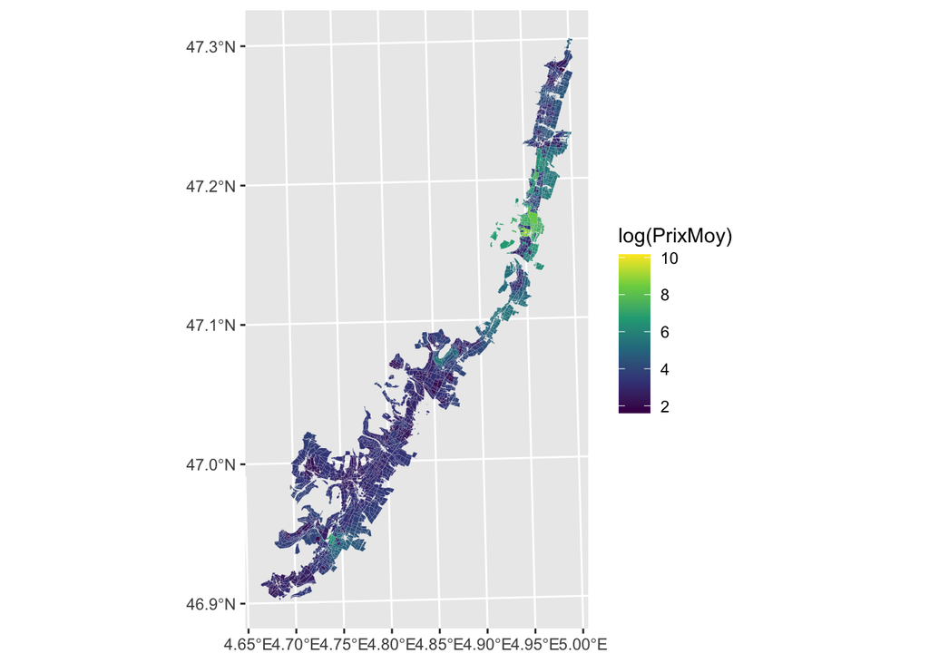

```r
ggplot(data = vignobles) +
  geom_sf(aes(fill = log(PrixMoy)), lwd=0.01, colour="white")  +
  scale_fill_viridis_c(option = "viridis")
```

Pour des étiquettes réactives, on utilise `geom_text_repel`:

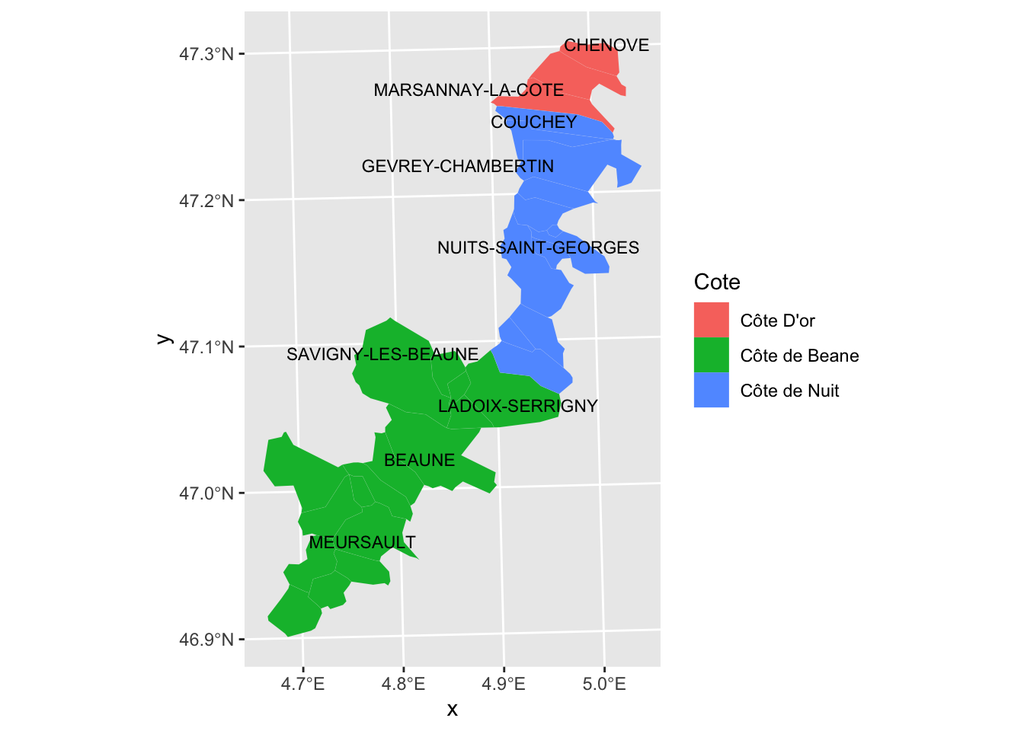

```r
ggplot(data = communes) +
  geom_sf(aes(fill = Cote), lwd=0.01, colour="white") +
  geom_text_repel(data = communes[communes$population > 1,],
                        aes(label = nom_comm, geometry = geometry),
                  stat = "sf_coordinates",size=3, colour="black")
```

## Création de variables niveau 2 à partir d’aggrégation de données niveau 1

Info sur la distribution des prix, des surfaces, des qualités physiques des vignobles, etc.

```r
Vignobles_par_communes <- as_tibble(vignobles) %>%
  group_by(LIBCOM) %>%
  summarise(aire_vignoble = sum(SURFACE),
            MoyPond_b = sum(SCORE_b * SURFACE) / sum(SURFACE),
            N_Parcelles = n(),
            Prix_moyen = mean(PrixMoy,na.rm=T),
            Prix_median = median(PrixMoy,na.rm=T),
            )
```

Info sur les appellations d’origine contrôlée:

```r
Vignobles_par_communes_par_AOC <- as_tibble(vignobles) %>%
  group_by(LIBCOM, NIVEAU) %>%
  summarise(N_Parcelles = n()
  ) %>%
  pivot_wider(names_from = NIVEAU, values_from = N_Parcelles) %>%
  replace_na(list(`Bourgogne` = 0,
                  `Grand cru`=0,
                  `Premier cru`=0,
                  `Village`=0,
                  `Coteaux b.`=0))
```

## Jointure et proportions d’AOC

```r
communes_final <- left_join(Vignobles_par_communes,
Vignobles_par_communes_par_AOC, by="LIBCOM") %>%
  left_join(communes,., by=c("nom_comm"="LIBCOM")) %>%
  mutate(share_Bourgogne = `Bourgogne` / N_Parcelles * 100,
         share_GdCru = `Grand cru` / N_Parcelles * 100,
         share_PmCru = `Premier cru` / N_Parcelles * 100,
         share_Village = `Village` / N_Parcelles * 100,
         share_Coteau = `Coteaux b.` / N_Parcelles * 100,
         share_PmGrCru = (`Premier cru`  + `Grand cru`) / N_Parcelles * 100,
         share_PmGrCruVill = (`Premier cru`  + `Grand cru` + `Village`) / N_Parcelles * 100)


head(communes_final)
```

|  | gid | id_geofla | code_comm | insee_com | nom_comm | statut | x_chf_lieu | y_chf_lieu | x_centroid | y_centroid | z_moyen | superficie | population | code_cant | code_arr | code_dept | nom_dept | code_reg | nom_region | Cote | aire_vignoble | MoyPond_b | N_Parcelles | Prix_moyen | Prix_median | Bourgogne | Grand cru | Premier cru | Village | … |
| --- | --- | --- | --- | --- | --- | --- | --- | --- | --- | --- | --- | --- | --- | --- | --- | --- | --- | --- | --- | --- | --- | --- | --- | --- | --- | --- | --- | --- | --- | --- |
| 1 | 563 | 563 | 054 | 21054 | BEAUNE | Sous-préfecture | 8396 | 66598 | 8395 | 66599 | 252 | 3110 | 21.9 | 98 | 1 | 21 | COTE-D'OR | 26 | BOURGOGNE | Côte de Beane | 69.21 | 74.29136 | 126 | 23.70813 | 23.0 | 34 | 0 | 42 | 41 | … |
| 2 | 573 | 573 | 267 | 21267 | FLAGEY-ECHEZEAUX | Commune simple | 8500 | 66758 | 8501 | 66751 | 230 | 799 | 0.5 | 24 | 1 | 21 | COTE-D'OR | 26 | BOURGOGNE | Côte de Nuit | 10.60 | 77.77055 | 26 | 1531.26923 | 1447.0 | 8 | 2 | 3 | 8 | … |
| 3 | 2196 | 2196 | 295 | 21295 | GEVREY-CHAMBERTIN | Chef-lieu canton | 8488 | 66825 | 8500 | 66818 | 300 | 2503 | 3.3 | 15 | 2 | 21 | COTE-D'OR | 26 | BOURGOGNE | Côte de Nuit | 58.18 | 75.85087 | 128 | 140.79015 | 81.0 | 26 | 9 | 26 | 61 | … |
| 4 | 2219 | 2219 | 464 | 21464 | NUITS-SAINT-GEORGES | Chef-lieu canton | 8478 | 66726 | 8468 | 66735 | 320 | 2038 | 5.6 | 24 | 1 | 21 | COTE-D'OR | 26 | BOURGOGNE | Côte de Nuit | 57.88 | 70.37153 | 121 | 261.34931 | 118.0 | 38 | 0 | 29 | 40 | … |
| 5 | 2228 | 2228 | 512 | 21512 | PULIGNY-MONTRACHET | Commune simple | 8334 | 66509 | 8338 | 66510 | 241 | 730 | 0.5 | 23 | 1 | 21 | COTE-D'OR | 26 | BOURGOGNE | Côte de Beane | 48.11 | 71.22580 | 88 | 115.74470 | 78.5 | 26 | 4 | 17 | 29 | … |
| 6 | 6127 | 6127 | 200 | 21200 | COUCHEY | Commune simple | 8498 | 66863 | 8482 | 66864 | 396 | 1258 | 1.2 | 15 | 2 | 21 | COTE-D'OR | 26 | BOURGOGNE | Côte D'or | 23.39 | 71.78541 | 81 | 68.33333 | 72.0 | 9 | 0 | 0 | 62 | … |

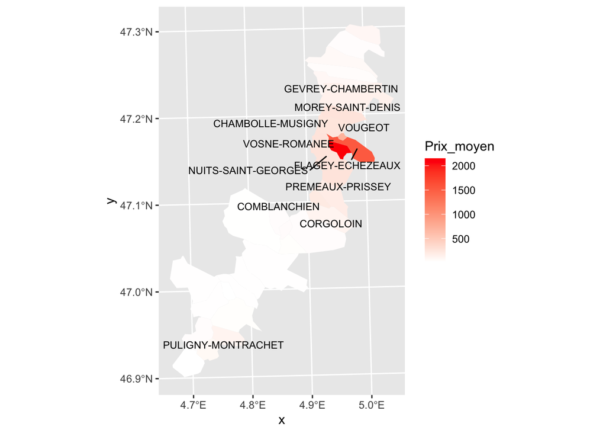

```r
# Prix moyen des vins estimés par commune
ggplot(data = communes_final) +
  geom_sf(aes(fill = Prix_moyen), lwd=0.01, colour="white")  +
  scale_fill_gradient(low = "white", high="red") +
  geom_text_repel(data = communes_final[communes_final$Prix_moyen > 100 ,],
                  aes(label = nom_comm, geometry = geometry),
                  stat = "sf_coordinates",size=3, colour="black")
```

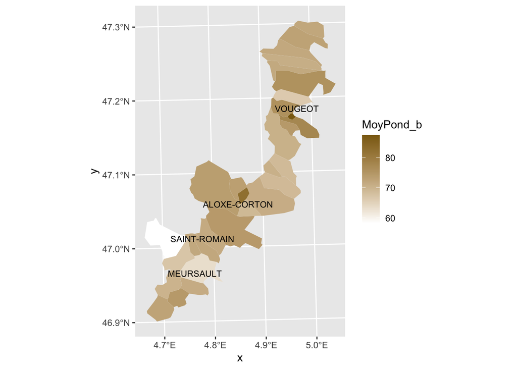

```r
# Qualité moyenne des parcelles par commune
ggplot(data = communes_final) +
  geom_sf(aes(fill = MoyPond_b), lwd=0.01, colour="white")  +
  scale_fill_gradient(low = "white", high="goldenrod4") +
  geom_text_repel(data = communes_final[communes_final$MoyPond_b > 80
                                      | communes_final$MoyPond_b < 65 ,],
                  aes(label = nom_comm, geometry = geometry),
                  stat = "sf_coordinates",size=3, colour="black")
```

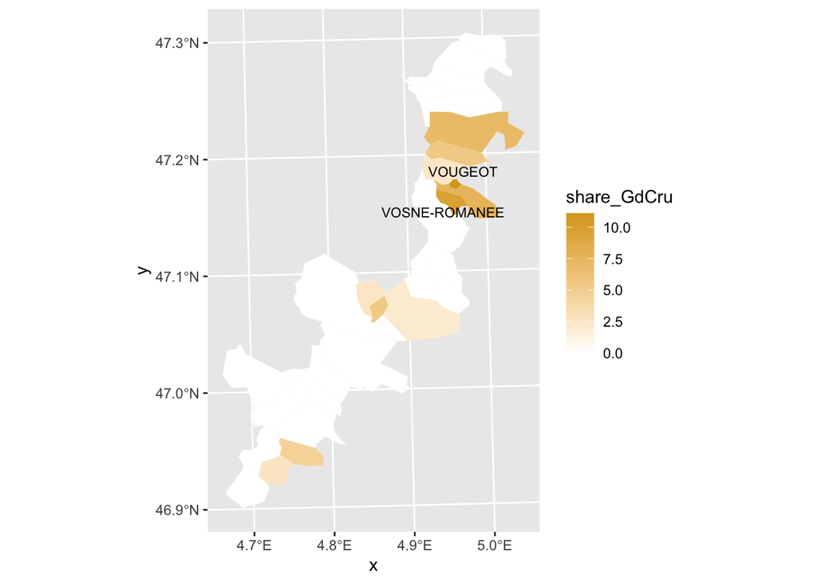

```r
# Proportion de parcelles en grand cru par commune
ggplot(data = communes_final) +
  geom_sf(aes(fill = share_GdCru), lwd=0.01, colour="white")  +
  scale_fill_gradient(low = "white", high="goldenrod") +
  geom_text_repel(data = communes_final[communes_final$share_GdCru > 8 ,],
                  aes(label = nom_comm, geometry = geometry),
                  stat = "sf_coordinates",size=3, colour="black")
```

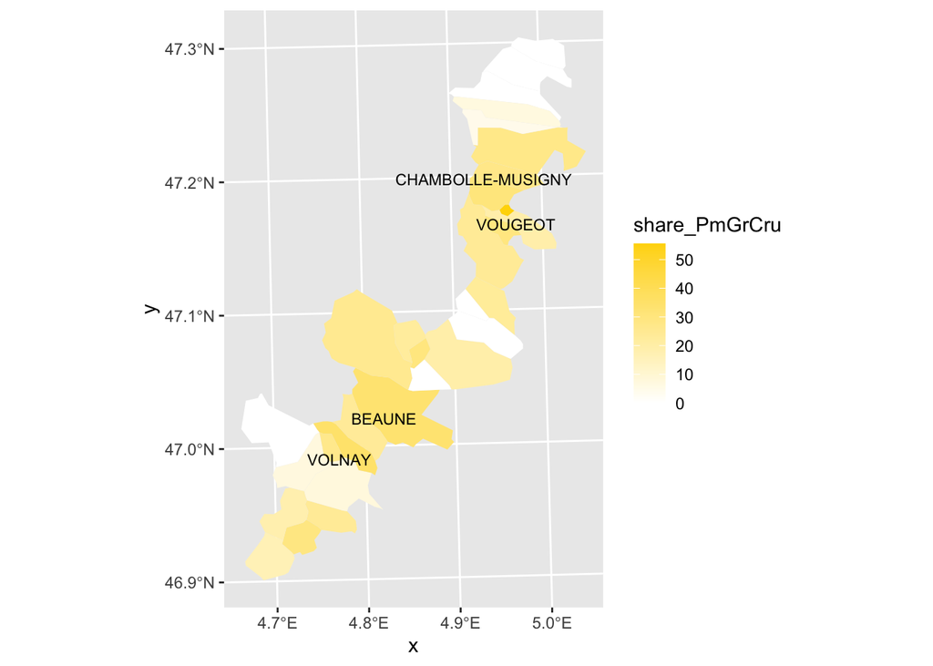

```r
# Proportion de parcelles en premier ou grand cru par commune
ggplot(data = communes_final) +
  geom_sf(aes(fill = share_PmGrCru), lwd=0.01, colour="white")  +
  scale_fill_gradient(low = "white", high="gold") +
  geom_text_repel(data = communes_final[communes_final$share_PmGrCru > 30 ,],
                  aes(label = nom_comm, geometry = geometry),
                  stat = "sf_coordinates",size=3, colour="black")
```

## Rapatriation des données communes au niveau vignoble

```r
communes_final_tib <- as_tibble(communes_final) %>%
  select(-geometry)

vignobles_final <- left_join(vignobles,communes_final_tib,
                              by=c("LIBCOM"= "nom_comm"))

summary(vignobles_final)
```

```
##                              Concat                     LIBCOM
##  1AUXEY-DURESSESCORLOIN         :   1   MEURSAULT          : 158
##  1AUXEY-DURESSESDERRIERE LE BOIS:   1   GEVREY-CHAMBERTIN  : 128
##  1AUXEY-DURESSESEN CHAIGNUT     :   1   BEAUNE             : 126
##  1AUXEY-DURESSESEN FRIVOLE      :   1   NUITS-SAINT-GEORGES: 121
##  1AUXEY-DURESSESEN MORVIN       :   1   SAINT-AUBIN        : 121
##  1AUXEY-DURESSESEN POCHENOT     :   1   (Other)            :1727
##  (Other)                        :2385   NA's               :  10
##             NOM               NIVEAU        SURFACE          SCORE_b
##  LE VILLAGE   :  26   Bourgogne  : 624   Min.   :0.0000   Min.   :18.40
##  LES CRAIS    :  10   Coteaux b. : 319   1st Qu.:0.1300   1st Qu.:67.90
##  LES CRAS     :   8   Grand cru  :  37   Median :0.3100   Median :73.20
##  SOUS LA VELLE:   8   Premier cru: 410   Mean   :0.4773   Mean   :71.89
##  LES PERRIERES:   7   Village    :1001   3rd Qu.:0.6100   3rd Qu.:76.60
##  (Other)      :2331                      Max.   :7.2000   Max.   :94.22
##  NA's         :   1
##             Source        PrixMoy             gid          id_geofla
##  guide_hachette: 416   Min.   :    5.0   Min.   :  563   Min.   :  563
##  interpolation :1942   1st Qu.:   23.0   1st Qu.: 6720   1st Qu.: 6720
##  wine_search   :  33   Median :   36.0   Median :14392   Median :14392
##                        Mean   :  154.4   Mean   :10484   Mean   :10484
##                        3rd Qu.:   87.0   3rd Qu.:14597   3rd Qu.:14597
##                        Max.   :25960.0   Max.   :14749   Max.   :14749
##                        NA's   :4         NA's   :10      NA's   :10
##    code_comm      insee_com                 statut       x_chf_lieu
##  412    : 158   21412  : 158   Chef-lieu canton: 257   Min.   :8291
##  295    : 128   21295  : 128   Commune simple  :1998   1st Qu.:8342
##  054    : 126   21054  : 126   Sous-préfecture : 126   Median :8396
##  464    : 121   21464  : 121   NA's            :  10   Mean   :8405
##  541    : 121   21541  : 121                           3rd Qu.:8480
##  (Other):1727   (Other):1727                           Max.   :8516
##  NA's   :  10   NA's   :  10                           NA's   :10
##    y_chf_lieu      x_centroid     y_centroid       z_moyen        superficie
##  Min.   :66472   Min.   :8288   Min.   :66477   Min.   :222.0   Min.   :  90
##  1st Qu.:66555   1st Qu.:8338   1st Qu.:66553   1st Qu.:256.0   1st Qu.: 765
##  Median :66641   Median :8395   Median :66642   Median :300.0   Median :1006
##  Mean   :66654   Mean   :8404   Mean   :66655   Mean   :306.2   Mean   :1353
##  3rd Qu.:66758   3rd Qu.:8477   3rd Qu.:66751   3rd Qu.:355.0   3rd Qu.:1962
##  Max.   :66897   Max.   :8514   Max.   :66899   Max.   :464.0   Max.   :3619
##  NA's   :10      NA's   :10     NA's   :10      NA's   :10      NA's   :10
```

[output cut: 41 more lines]

```
##  Min.   :11.54   Min.   : 0.000   Min.   : 0.000   Min.   :25.00
##  1st Qu.:32.77   1st Qu.: 4.688   1st Qu.: 7.207   1st Qu.:46.84
##  Median :39.24   Median :11.570   Median :23.529   Median :63.22
##  Mean   :41.83   Mean   :13.398   Mean   :18.690   Mean   :60.52
##  3rd Qu.:48.98   3rd Qu.:17.857   3rd Qu.:27.473   3rd Qu.:73.75
##  Max.   :76.54   Max.   :44.444   Max.   :55.556   Max.   :86.49
##  NA's   :10      NA's   :10       NA's   :10       NA's   :10
##           geometry
##  MULTIPOLYGON :2391
##  epsg:2154    :   0
##  +proj=lcc ...:   0
##
##
##
##
```

# Modélisation multiniveaux

## variable a expliquer: le prix moyen du 🍷

```r
summary(vignobles_final$PrixMoy)
```

```
##    Min. 1st Qu.  Median    Mean 3rd Qu.    Max.    NA's
##     5.0    23.0    36.0   154.4    87.0 25960.0       4
```

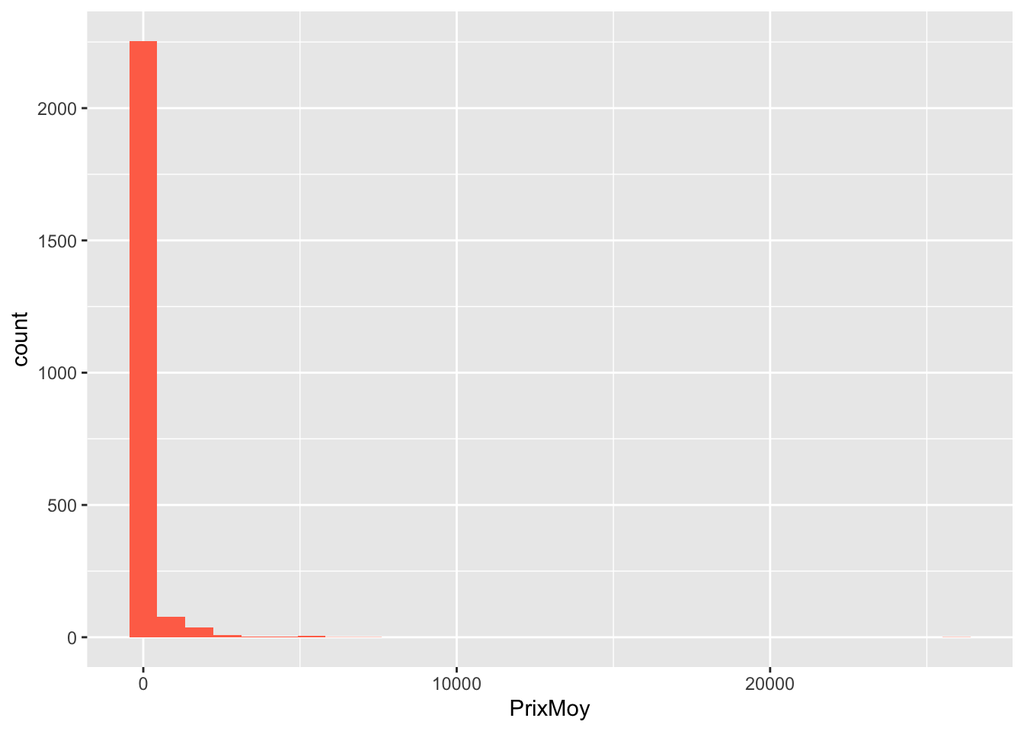

```r
ggplot(data=vignobles_final, aes(x=PrixMoy)) +
  geom_histogram(fill="coral1")
```

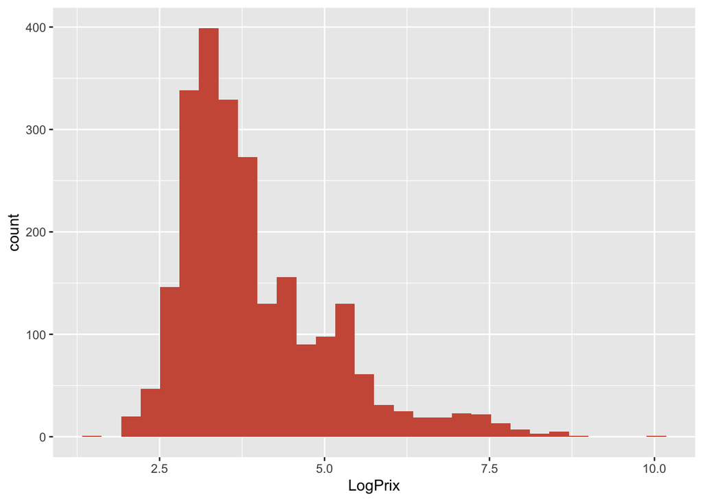

```r
# Passage en log pour une distribution plus normale
vignobles_final$LogPrix <- log(vignobles_final$PrixMoy)

ggplot(data=vignobles_final, aes(x=LogPrix)) +
  geom_histogram(fill="coral3") +
  geom_vline(aes(xintercept=mean(LogPrix)),
             color="black", linetype="dashed", size=1)
```

## variables explicatives niveau 1:

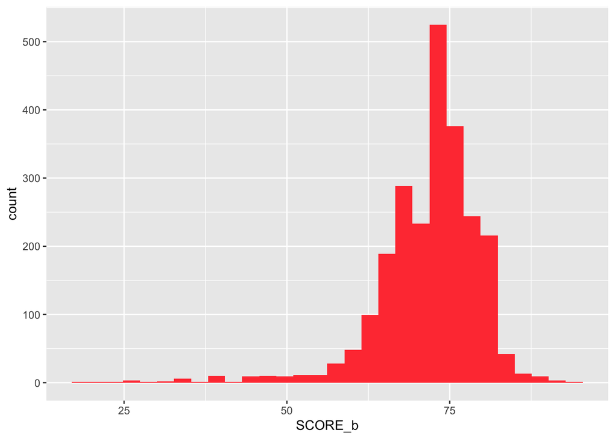

```r
#Score qualité geographique (pente, geologie, pedologie, precipitations):
ggplot(data=vignobles_final, aes(x=SCORE_b)) +
  geom_histogram(fill="brown1")
```

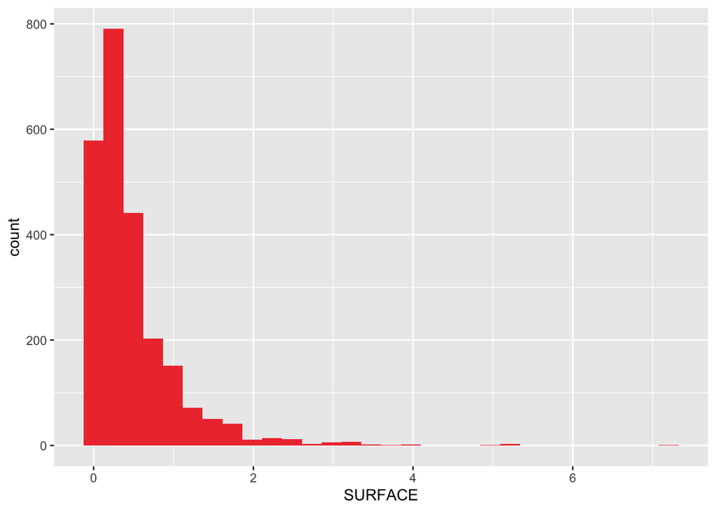

```r
#Surface:
ggplot(data=vignobles_final, aes(x=SURFACE)) +
  geom_histogram(fill="brown2")
```

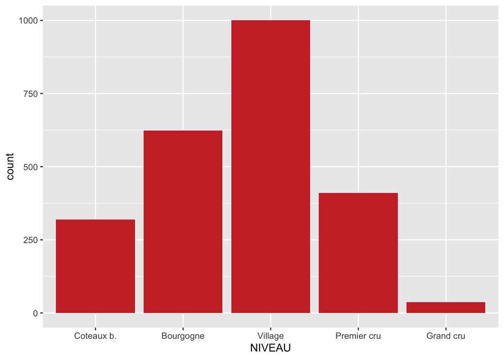

```r
#Niveau d'aoc:
positions <- c("Coteaux b.", "Bourgogne", "Village",
               "Premier cru", "Grand cru")
ggplot(data=vignobles_final, aes(x=NIVEAU)) +
  geom_bar(fill="brown3") +
  scale_x_discrete(limits = positions)
```

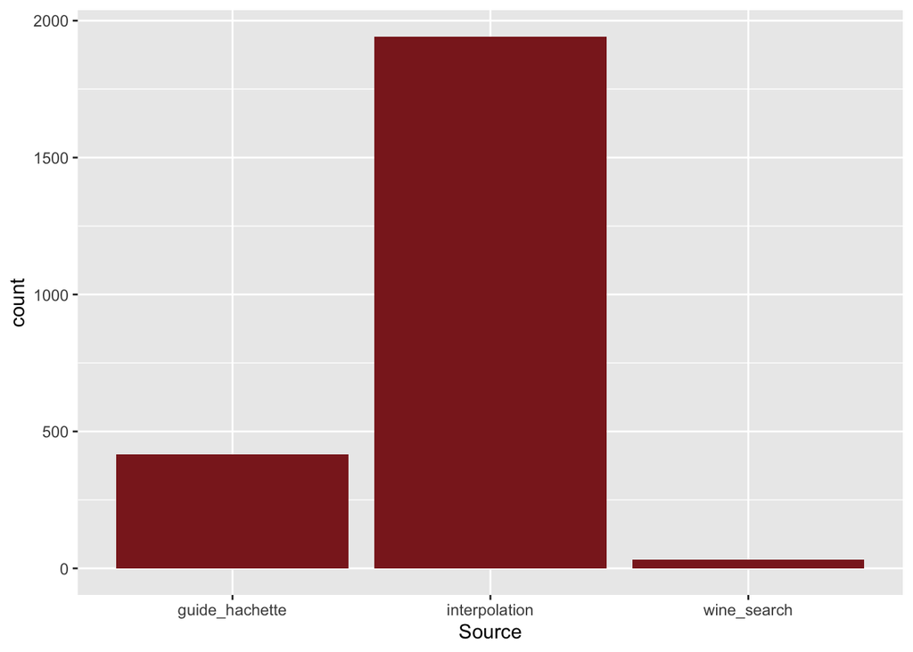

```r
#Source info prix:
ggplot(data=vignobles_final, aes(x=Source)) +
   geom_bar(fill="brown4")
```

## variables explicatives niveau 2:

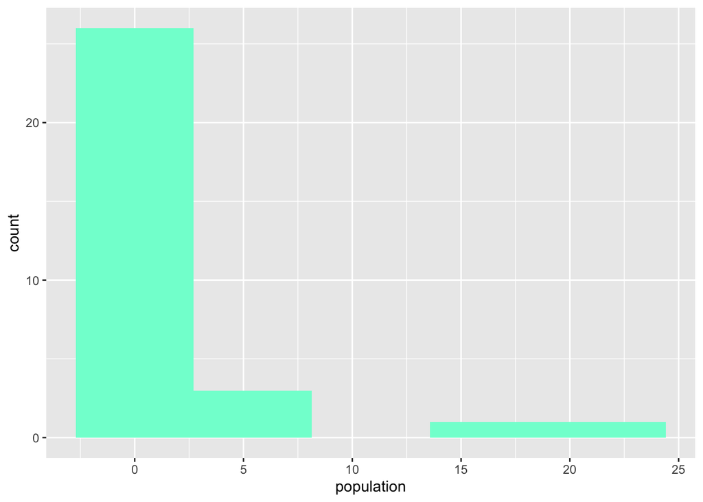

```r
#Population de la commune
ggplot(data=communes_final, aes(x=population)) +
  geom_histogram(fill="aquamarine1", bins = 5)
```

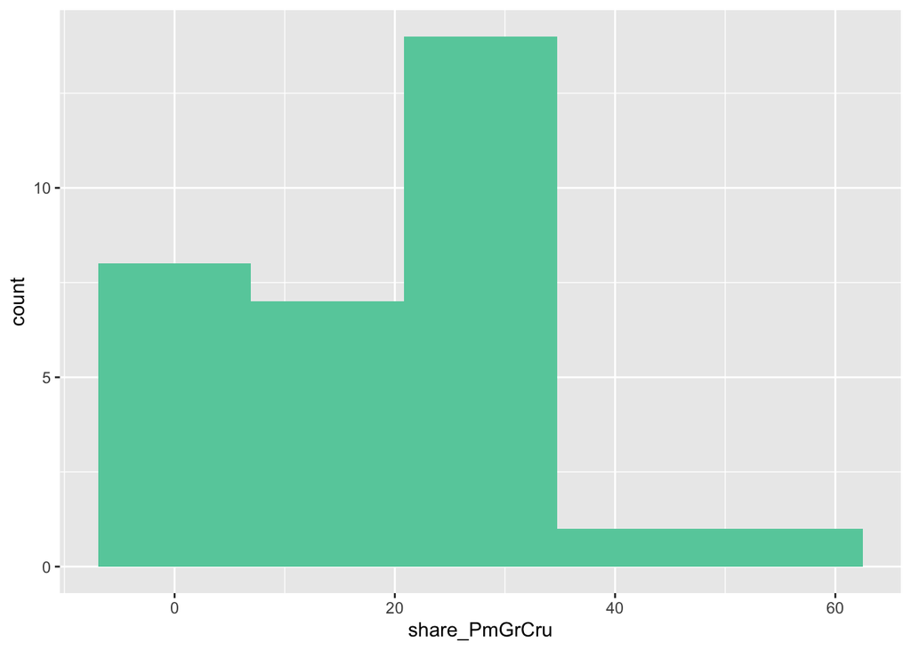

```r
#Part de grand et premier cru de la commune
ggplot(data=communes_final, aes(x=share_PmGrCru)) +
  geom_histogram(fill="aquamarine3", bins = 5)
```

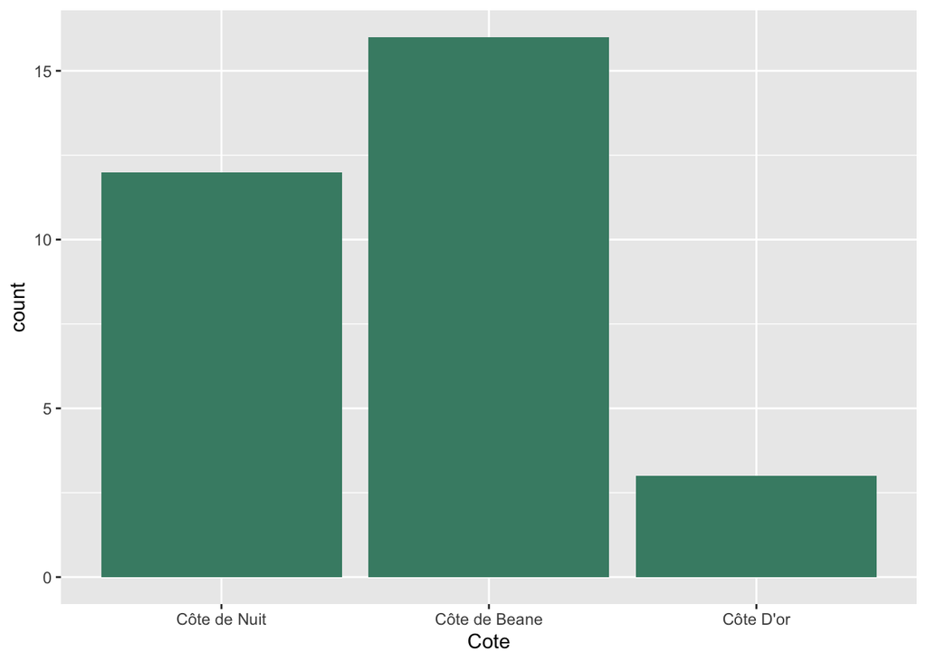

```r
#Cote de nuit ou cote de beaune:
pos_cote <- c("Côte de Nuit", "Côte de Beane", "Côte D'or")
ggplot(data=communes_final, aes(x=Cote)) +
  geom_bar(fill="aquamarine4") +
  scale_x_discrete(limits = pos_cote)
```

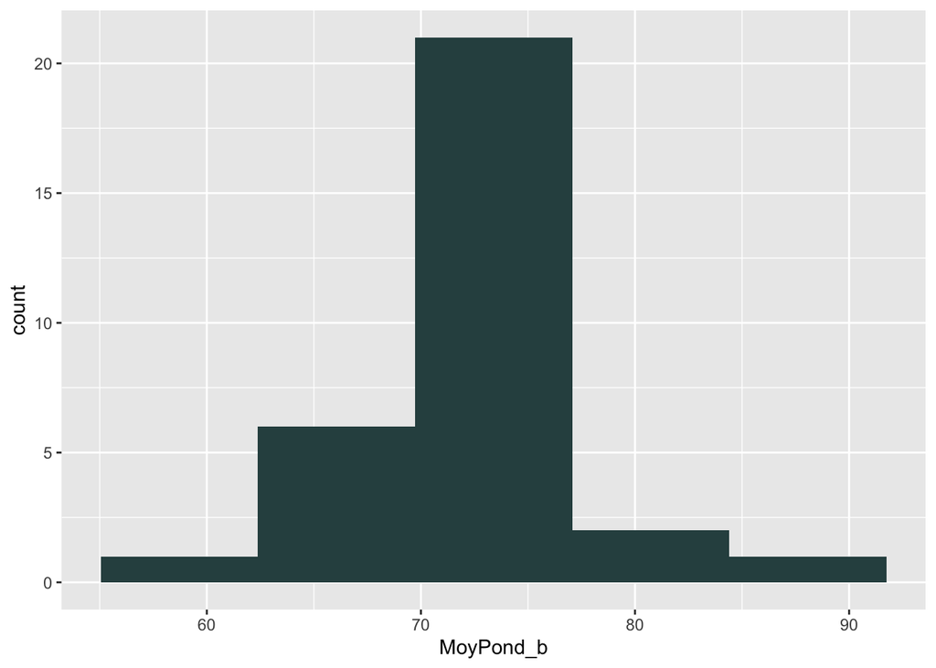

```r
#Qualite moyenne de la commune
ggplot(data=communes_final, aes(x=MoyPond_b)) +
  geom_histogram(fill="darkslategrey", bins = 5)
```